# final-project

## Albedo and absolute magnitudes of asteroids.

only 6 of them come within the orbit of the to earth. still pretty far. lets check their Alberto to see how reflective they are. that would make them easier to see.

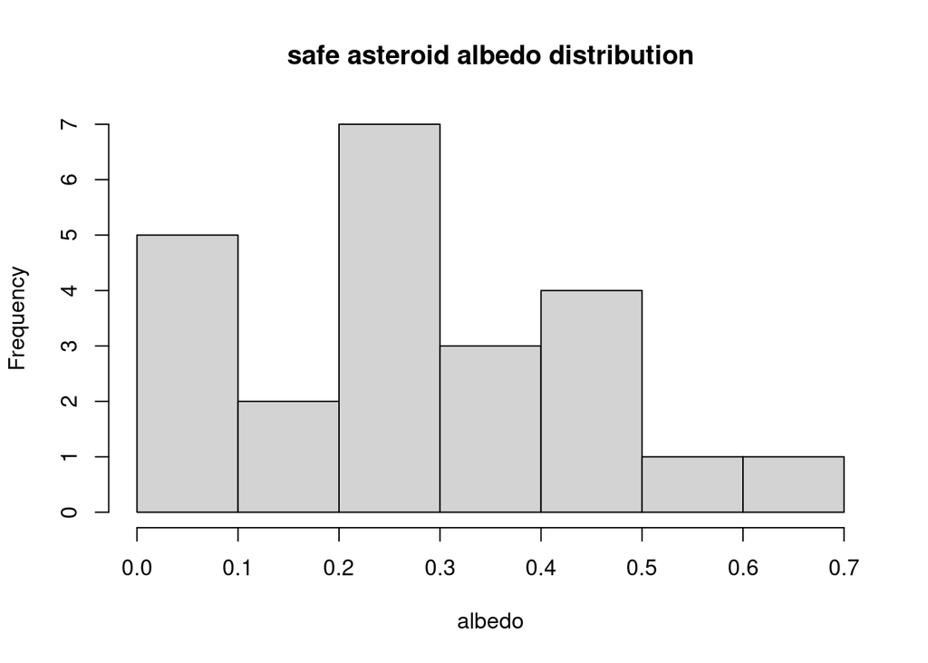

```r
hist(small[small$threatlevel=="safe", "albedo"], main = "safe asteroid albedo distribution", xlab="albedo")
```

```r
summary(small[small$threatlevel=="safe", "albedo"])
```

```
##    Min. 1st Qu.  Median    Mean 3rd Qu.    Max.
##  0.0600  0.1580  0.2870  0.2856  0.4110  0.6090
```

this graph is showing us that these small asteroids are quite reflective. now lets look at their absolute magnitude or “H”. in this case, higher means less bright. for caparison the suns absolute magnitude is -27.

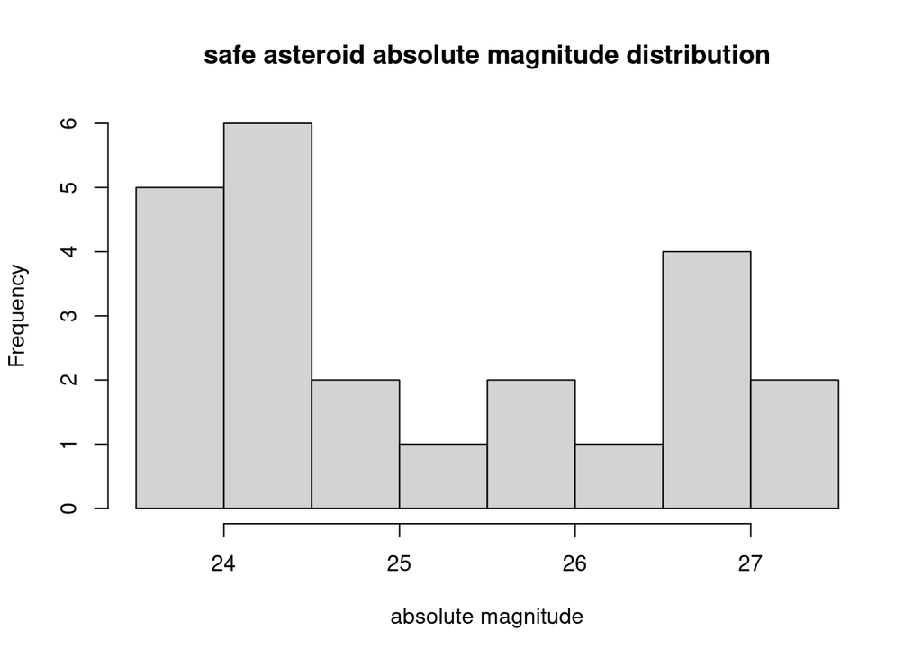

```r
hist(small[small$threatlevel=="safe", "H"], main = "safe asteroid absolute magnitude distribution", xlab="absolute magnitude")
```

```r
summary(small[small$threatlevel=="safe", "H"])
```

```
##    Min. 1st Qu.  Median    Mean 3rd Qu.    Max.
##   23.60   24.15   24.60   25.17   26.35   27.50
```

unsurprisingly, the small “safe” asteroids are not bright at all.

for comparison, lets look at the big “destroy” asteroids in the same way.

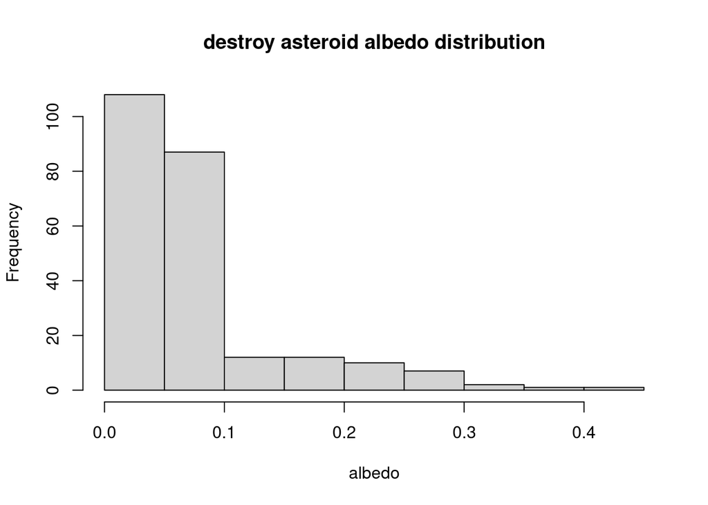

```r
hist(small[small$threatlevel=="destroy", "albedo"], main = "destroy asteroid albedo distribution", xlab="albedo")
```

```r
summary(small[small$threatlevel=="destroy", "albedo"])
```

```
##    Min. 1st Qu.  Median    Mean 3rd Qu.    Max.
## 0.02200 0.04308 0.05250 0.07880 0.07060 0.42280
```

this data is showing us that the albedo of the bigger “destroy” asteroids are less reflective then the small “safe” asteroids. now lets look at their absolute magnitude.

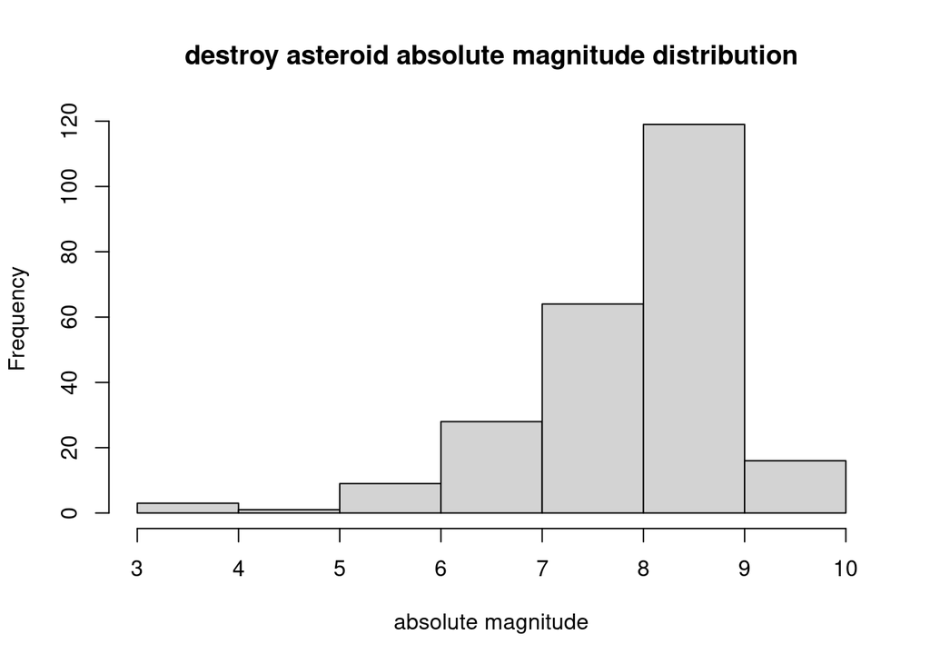

```r
hist(small[small$threatlevel=="destroy", "H"], main = "destroy asteroid absolute magnitude distribution", xlab="absolute magnitude")
```

```r
summary(small[small$threatlevel=="destroy", "H"])
```

```
##    Min. 1st Qu.  Median    Mean 3rd Qu.    Max.
##   3.000   7.500   8.200   7.931   8.625   9.500
```

this graph however, tells shows us that the bigger asteroids are much brighter. i was expecting the bigger asteroids to have a lower absolute magnitude but its surprising to see that the smaller asteroids are more reflective.

now lets compare the albedo of all of the different sized asteroids.

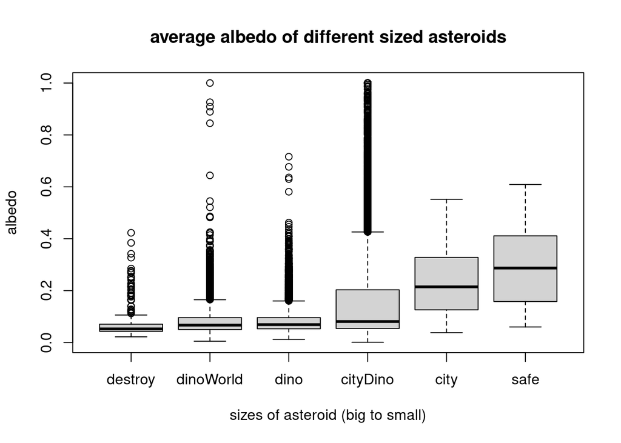

```r
tmp=factor(small$threatlevel,levels = c("destroy","dinoWorld","dino","cityDino","city","safe"))
boxplot(data=small,albedo~tmp, main = "average albedo of different sized asteroids", xlab = "sizes of asteroid (big to small)", ylab = "albedo")
```

from this graph we can see that smaller asteroids have a larger albedo.

now lets compare the absolute magnitude of all of the different sized asteroids.

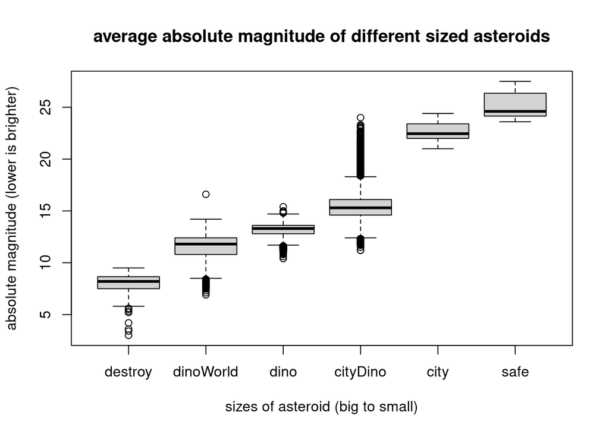

```r
tmp=factor(small$threatlevel,levels = c("destroy","dinoWorld","dino","cityDino","city","safe"))
boxplot(data=small,H~tmp, main = "average absolute magnitude of different sized asteroids", xlab = "sizes of asteroid (big to small)", ylab = "absolute magnitude (lower is brighter)")
```

from this graph we can see that the larger asteroids have a lower absolute magnitude.

## Conclustion aboout albedo and absolute magnitude in different sized asteroids.

its not that surprising to see that as asteroids get larger, their absolute magnitudes get brighter. however, i was not expecting the as asteroids get bigger their albedo gets lower and less reflective. it would be interesting to know why this is. my first guess is that it has something to do with what the asteroid is made of. unfortunately my data set does not have information about that. when we compared the asteroids with if they were neo’s or not we saw that all of the safe and city ones were neo’s. so maybe another reason smaller asteroids have higher albedos is because the only ones we can see are relatively close to the sun allowing them to reflect more sunlight for us to see. further analysis would need to be done to confirm this.

## Destroy earth category asteroid analysis

lets find out if there are any asteroids in this data set that are both a near earth object and also is big enough to destroy earth.

```r
table(small$destroy, small$neo)
```

```
##
##          FALSE   TRUE
##   FALSE 130163    739
##   TRUE     240      0
```

this is good news for us. from the table we can see that there are no known asteroids that are big enough to destroy the earth and are also a near earth object.

however, just because they aren’t near earth doesn’t necessarily mean they cant still be hazards. lets check if there are any earth destroying asteroids that our potentially hazardous.

```r
table(small$destroy, small$pha)
```

```
##
##          FALSE   TRUE
##   FALSE 130721    181
##   TRUE     240      0
```

this is also good news for earth. it also makes sense. if none of them are near earth objects it would make sense that thier also not pha’s. just for fun lets check if there are any of these asteroids come within a lunar unit of earth orbit.

```r
table(small$destroy, small$moon)
```

```
##
##          FALSE   TRUE
##   FALSE 130883     19
##   TRUE     240      0
```

## Destroy earth asteroid conclusion

as expected we can see from this table no destroy asteroids even come within the moons orbit. we probably could have guessed that from the previous 2 tables but its good to really confirm it.

## Lunar orbit asteroids

in the last table it shows that there any only 19 asteroids in the whole data set that even come within a lunar orbit of earth. lets see what kind of asteroids they are.

```r
table(small$threatlevel, small$moon)
```

```
##
##              FALSE   TRUE
##   city          46      0
##   cityDino  120989     13
##   destroy      240      0
##   dino        5596      0
##   dinoWorld   4235      0
##   safe          17      6
```

6 of them are safe so that’s good news. the remaining 13 are all cityDino. that’s a little concerning. lets focus on those.

lets check how many cityDino asteroids are also near earth objects.

```r
table(small$cityDino, small$neo)
```

```
##
##          FALSE   TRUE
##   FALSE  10069     71
##   TRUE  120334    668
```

this table does not help us very much because clearly for an asteroid to be considered a neo it can be further away then just a lunar unit.

lets check the overlap between neo’s and asteroids that come within a lunar unit. it would make sense to see that all asteroids that come within a lunar unit is also considered a near earth object. first ill just take a look at how much asteroids that come within a lunar unit and compare that number to asteroids that are both neo’s and come within a lunar unit.

```r
table(small$moon)
```

```
##
##  FALSE   TRUE
## 131123     19
```

```r
table(small$neo, small$moon)
```

```
##
##          FALSE   TRUE
##   FALSE 130403      0
##   TRUE     720     19
```

so i was right in assuming that all moon asteroids are also neo’s. all 19 of them were also neo’s.

so now that we know this lets see how much of the cityDino asteroids are also pha’s

```r
table(small$cityDino, small$pha)
```

```
##
##          FALSE   TRUE
##   FALSE  10132      8
##   TRUE  120829    173
```

we can see that there are 173 city dino asteroids that we need to be worried about. when we compared city dino asteroids to neo’s there were 668. these two categories do not necessarily overlap. there could be pha asteroids that aren’t neo’s. lets check and see.

lets compare neo’s with pha’s

```r
summary(small$pha)
```

```
##    Mode   FALSE    TRUE
## logical  130961     181
```

```r
table(small$neo, small$pha)
```

```
##
##          FALSE   TRUE
##   FALSE 130403      0
##   TRUE     558    181
```

nope, just like with the destroy asteroids. all pha asteroids are also neo’s.

low lets check and see how much of the cityDino asteroids come within a lunar unit.

```r
table(small$cityDino, small$moon)
```

```
##
##          FALSE   TRUE
##   FALSE  10134      6
##   TRUE  120989     13
```

so out of the 173 cityDino asteroids that are potential hazards only 13 come within a lunar unit. lets focus on those.

now lets look at how much pha asteroids there are total and compare that to how much of them are also moon asteroids.

```r
summary(small$pha)
```

```
##    Mode   FALSE    TRUE
## logical  130961     181
```

```r
table(small$pha, small$moon)
```

```
##
##          FALSE   TRUE
##   FALSE 130954      7
##   TRUE     169     12
```

so out of the 181 pha asteroids only 12 of them come within the orbit of the moon. this kind of doesn’t make sense because when we looked at cityDino asteroids that came within a lunar unit there were 13 of them. for some reason one of the cityDino asteroids that come within a lunar unit is not considered a pha in this data set. maybe one of my cityDino asteroids are too small to be considered a pha. lets see if any city asteroids are pha’s. city asteroids are smaller so if that is the case none of them should be pha’s.

```r
table(small$city, small$pha)
```

```
##
##          FALSE   TRUE
##   FALSE 130923    173
##   TRUE      38      8
```

nope, that’s not it. even some smaller asteroids are considered pha’s. there must be another variable that the data set used to determine whats a pha that im not taking into account. or maybe the data set mislabeled one as not being a pha when it should. in any case there are 12-13 cityDino asteroids that are potential hazards and also come within a lunar orbit of earth. just to put that distance into perspective, every planet in the solar system put side by side fits in between the earth and the moon. so even if an steroid does come within the moon and earth it would still be very unlikely for it to hit the earth.

## Conclusion

in conclusion, the likelihood that the earth will be hit with an asteroid anytime soon is very low. from the analysis I’ve shown in this presentation the most likely candidate to hit the earth is one between the size to destroy a city and the size that took out the dinosaurs. as long as NASA and other space agencies keep tracking these asteroids and projects like “DART” keep getting worked on we should be safe when and if the day comes that there is an asteroid big enough to cause damage is on a collision corse with earth.